# Question

A student is taking a multiple choice test with 300 questions. Each question has 3 choices. You want to detect whether the student does better than random guessing, so you decide to run a hypothesis test with a significance level of 0.1.

Then, the student takes the test and gets 111 questions correct.

## Answerlist

- What kind of hypothesis test is appropriate?
- State the hypotheses
- Determine the $p$-value.
- Decide whether we reject or retain the null hypothesis.
- Do we think the student did better than random guessing?

# Solution

This is a right-tail (one-tail) proportion test because we only care whether the student does better than random.

Determine the null population proportion.
$$p_0 = \frac{1}{3} = 0.333$$

State the hypotheses.
$$H_0 ~~~\text{ claims } ~~~ p = 0.333$$
$$H_\text{A}~~~\text{ claims } ~~~ p > 0.333$$
Determine the standard error.
$$\sigma_{\hat{p}} = \sqrt{\frac{p_0(1-p_0)}{n}} = \sqrt{\frac{0.333(1-0.333)}{300}} = 0.0272$$
Determine the sample proportion.
$$\hat{p} = \frac{111}{300} = 0.37$$

Determine a $z$ score. For simplicity, we ignore the continuity correction.
$$z = \frac{\hat{p}-p_0}{\sigma_{\hat{p}}} = \frac{0.37-0.333}{0.0272} = 1.36$$
The $p$-value is a right area.

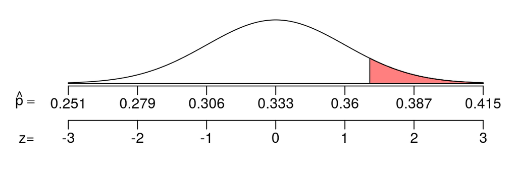

To determine that right area, we use the z table.
$$\begin{aligned}
p\text{-value} &= P\left(\hat{p} > 0.37\right) \\
&= P(Z > 1.36)\\
&= 1 - P(Z<1.36) \\
&= 0.0869
\end{aligned}$$
Compare $p$-value to $\alpha$ (which is 0.1).
$$p\text{-value} < \alpha$$
Make the conclusion: we reject the null hypothesis.

We think the student did better than random guessing typically allows.

## Answerlist

- Right tail (one-tail) proportion test
- Hypotheses: $H_0 \text{ claims } p = 0.333$ and $H_\text{A} \text{ claims } p > 0.333$.
- The $p$-value is 0.0869
- We reject the null hypothesis.
- We think the student did better than random guessing typically allows.

# Meta-information

extype: string exsolution: We think the student did better than random guessing typically allows. exname: p hyp test right extol: 0.01